# vignette - chunkfactory

irene cruz

27-05-25

```r
library(chunkfactory)
library(tidyverse)
```

```r
utils::data(package = "palmerpenguins", "penguins")
penguins$pes <- 1
```

# 1 Objectives

The package `chunkfactory`is meant to minimize the coding for markdown documents where a handful of functions need to be executed iteratively. This could facilitate, for instance, the production of documents for the exploration of bivariate descriptive statistics.

It solves 2 problems:

- repetitive code when performing the same operations on multiple combinations of variables
- presenting figures and tables in RMD when repeating functions on a list

The chunk factory can be applied to custom functions, or can be used with the built-in descriptive statistics functions for weighted data. Let’s see the two cases.

# 2 Execute any function as a chunk factory

1. We can use the chunk factory on any custom function that generates the collection of results we need. The only restriction is that the `data` argument needs to be passed as a **text string**. Then the function needs to evaluate the text string.

For example, we’ll build a function that, for every pair of variables returns:

- a linear regression model
- a formatted table of model results
- a tibble of model coefficients
- a predicted means plot

```r
myfunc <- function(data_name, v1, v2){
  data <- get(data_name)

  myformula <- as.formula(glue::glue("{v1} ~ {v2}"))
  res1 <- lm(myformula, data = data)
  res2 <- sjPlot::tab_model(res1, use.viewer = F)
  res3 <- broom::tidy(res1)
  res4 <- sjPlot::plot_model(res1, type = "eff", terms = v2)

  return(list(res1, res2, res3, res4))
}
```

If we were to simply execute `myfunc()`and get the list of results it produces as is, we’d find each element is preceded by the aesthetically unpleasant `[[x]]`, and table outputs are not printed following document guidelines (i.e. paged data frames):

```r
myfunc("penguins", "flipper_length_mm", "species")
```

```
## [[1]]
##
## Call:
## lm(formula = myformula, data = data)
##
## Coefficients:
##      (Intercept)  speciesChinstrap     speciesGentoo
##           189.95              5.87             27.23
##
##
## [[2]]
##
## [[3]]
## # A tibble: 3 × 5
##   term             estimate std.error statistic   p.value
##   <chr>               <dbl>     <dbl>     <dbl>     <dbl>
## 1 (Intercept)        190.       0.540    351.   0
## 2 speciesChinstrap     5.87     0.970      6.05 3.79e-  9
## 3 speciesGentoo       27.2      0.807     33.8  1.84e-110
##
## [[4]]
```

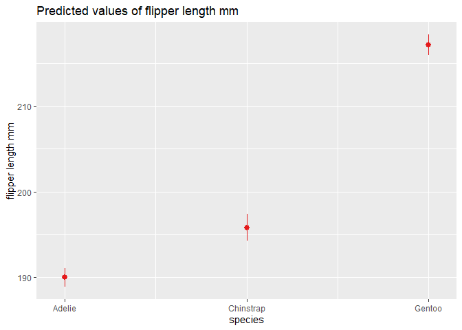

chunkfactory will help us reproduce results in an optimal way for a rmd document, while minimising the iteration of code.

2. In order to create a chunk factory, first we’ll need to define a list of parameters to iterate upon. Remember that the parameters need to be named exactly as the function arguments’ names, and follow the same order:

```r
myfunc_params <- list(
  data_name = "penguins",
  v1        = c("flipper_length_mm", "bill_length_mm"),
  v2        = c("species", "island", "sex")
  )
```

Next we’ll only need to execute our custom function with our list of parameters:

```r
myres <- fabrica_chunks_myfunc(
  myfunc = myfunc,
  param_list = myfunc_params,
  title_level = 2)
```

This generates a character vector containing the markdown, chunks and code to be evaluated. See a sample:

```r
head(myres)
```

````
## [1] "\n\n## penguins.flipper_length_mm.species\n\n```{r echo = TRUE}\n\neval(parse(text = 'reslist[[1]][[1]]'))\neval(parse(text = 'reslist[[1]][[2]]'))\neval(parse(text = 'reslist[[1]][[3]]'))\neval(parse(text = 'reslist[[1]][[4]]'))\n```\n\n"
## [2] "\n\n## penguins.bill_length_mm.species\n\n```{r echo = TRUE}\n\neval(parse(text = 'reslist[[2]][[1]]'))\neval(parse(text = 'reslist[[2]][[2]]'))\neval(parse(text = 'reslist[[2]][[3]]'))\neval(parse(text = 'reslist[[2]][[4]]'))\n```\n\n"
## [3] "\n\n## penguins.flipper_length_mm.island\n\n```{r echo = TRUE}\n\neval(parse(text = 'reslist[[3]][[1]]'))\neval(parse(text = 'reslist[[3]][[2]]'))\neval(parse(text = 'reslist[[3]][[3]]'))\neval(parse(text = 'reslist[[3]][[4]]'))\n```\n\n"
## [4] "\n\n## penguins.bill_length_mm.island\n\n```{r echo = TRUE}\n\neval(parse(text = 'reslist[[4]][[1]]'))\neval(parse(text = 'reslist[[4]][[2]]'))\neval(parse(text = 'reslist[[4]][[3]]'))\neval(parse(text = 'reslist[[4]][[4]]'))\n```\n\n"
## [5] "\n\n## penguins.flipper_length_mm.sex\n\n```{r echo = TRUE}\n\neval(parse(text = 'reslist[[5]][[1]]'))\neval(parse(text = 'reslist[[5]][[2]]'))\neval(parse(text = 'reslist[[5]][[3]]'))\neval(parse(text = 'reslist[[5]][[4]]'))\n```\n\n"
## [6] "\n\n## penguins.bill_length_mm.sex\n\n```{r echo = TRUE}\n\neval(parse(text = 'reslist[[6]][[1]]'))\neval(parse(text = 'reslist[[6]][[2]]'))\neval(parse(text = 'reslist[[6]][[3]]'))\neval(parse(text = 'reslist[[6]][[4]]'))\n```\n\n"
````

## 2.1 penguins.flipper_length_mm.species

```r
eval(parse(text = 'reslist[[1]][[1]]'))
```

```
##
## Call:
## lm(formula = myformula, data = data)
##
## Coefficients:
##      (Intercept)  speciesChinstrap     speciesGentoo
##           189.95              5.87             27.23
```

```r
eval(parse(text = 'reslist[[1]][[2]]'))
```

|  | flipper length mm |  |  |
| --- | --- | --- | --- |
| Predictors | Estimates | CI | p |
| (Intercept) | 189.95 | 188.89 – 191.02 | **<0.001** |
| species [Chinstrap] | 5.87 | 3.96 – 7.78 | **<0.001** |
| species [Gentoo] | 27.23 | 25.65 – 28.82 | **<0.001** |
| Observations | 342 |  |  |
| R<sup>2</sup> / R<sup>2</sup> adjusted | 0.778 / 0.777 |  |  |

```r
eval(parse(text = 'reslist[[1]][[3]]'))
```

```
## # A tibble: 3 × 5
##   term             estimate std.error statistic   p.value
##   <chr>               <dbl>     <dbl>     <dbl>     <dbl>
## 1 (Intercept)        190.       0.540    351.   0
## 2 speciesChinstrap     5.87     0.970      6.05 3.79e-  9
## 3 speciesGentoo       27.2      0.807     33.8  1.84e-110
```

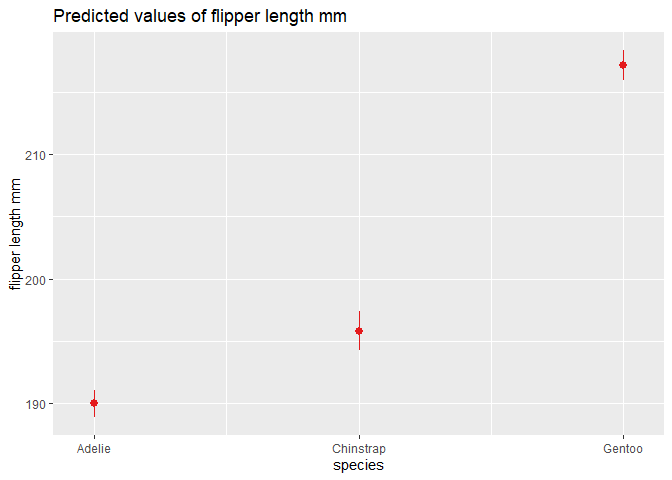

```r
eval(parse(text = 'reslist[[1]][[4]]'))
```

## 2.2 penguins.bill_length_mm.species

```r
eval(parse(text = 'reslist[[2]][[1]]'))
```

```
##
## Call:
## lm(formula = myformula, data = data)
##
## Coefficients:
##      (Intercept)  speciesChinstrap     speciesGentoo
##           38.791            10.042             8.713
```

```r
eval(parse(text = 'reslist[[2]][[2]]'))
```

|  | bill length mm |  |  |
| --- | --- | --- | --- |
| Predictors | Estimates | CI | p |
| (Intercept) | 38.79 | 38.32 – 39.27 | **<0.001** |
| species [Chinstrap] | 10.04 | 9.19 – 10.89 | **<0.001** |
| species [Gentoo] | 8.71 | 8.01 – 9.42 | **<0.001** |
| Observations | 342 |  |  |
| R<sup>2</sup> / R<sup>2</sup> adjusted | 0.708 / 0.706 |  |  |

```r
eval(parse(text = 'reslist[[2]][[3]]'))
```

```
## # A tibble: 3 × 5
##   term             estimate std.error statistic   p.value
##   <chr>               <dbl>     <dbl>     <dbl>     <dbl>
## 1 (Intercept)         38.8      0.241     161.  2.47e-322
## 2 speciesChinstrap    10.0      0.432      23.2 4.23e- 72
## 3 speciesGentoo        8.71     0.360      24.2 5.33e- 76
```

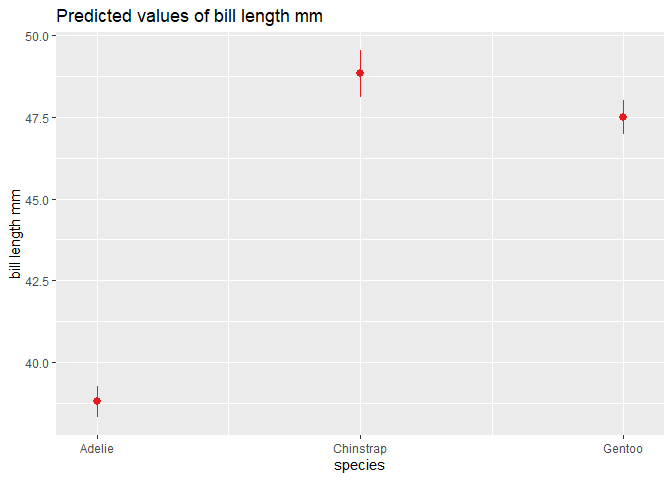

```r
eval(parse(text = 'reslist[[2]][[4]]'))
```

## 2.3 penguins.flipper_length_mm.island

```r
eval(parse(text = 'reslist[[3]][[1]]'))
```

```
##
## Call:
## lm(formula = myformula, data = data)
##
## Coefficients:
##     (Intercept)      islandDream  islandTorgersen
##          209.71           -16.63           -18.51
```

```r
eval(parse(text = 'reslist[[3]][[2]]'))
```

|  | flipper length mm |  |  |
| --- | --- | --- | --- |
| Predictors | Estimates | CI | p |
| (Intercept) | 209.71 | 208.01 – 211.40 | **<0.001** |
| island [Dream] | -16.63 | -19.23 – -14.04 | **<0.001** |
| island [Torgersen] | -18.51 | -22.02 – -15.00 | **<0.001** |
| Observations | 342 |  |  |
| R<sup>2</sup> / R<sup>2</sup> adjusted | 0.376 / 0.372 |  |  |

```r
eval(parse(text = 'reslist[[3]][[3]]'))
```

```
## # A tibble: 3 × 5
##   term            estimate std.error statistic  p.value
##   <chr>              <dbl>     <dbl>     <dbl>    <dbl>
## 1 (Intercept)        210.      0.862     243.  0
## 2 islandDream        -16.6     1.32      -12.6 4.20e-30
## 3 islandTorgersen    -18.5     1.78      -10.4 4.04e-22
```

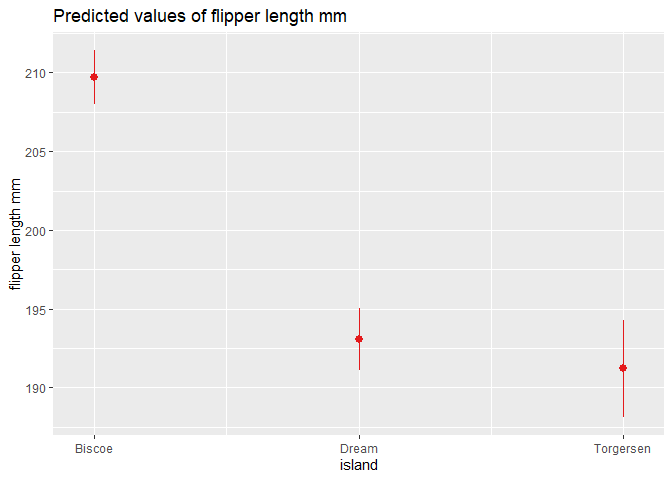

```r
eval(parse(text = 'reslist[[3]][[4]]'))
```

## 2.4 penguins.bill_length_mm.island

```r
eval(parse(text = 'reslist[[4]][[1]]'))
```

```
##
## Call:
## lm(formula = myformula, data = data)
##
## Coefficients:
##     (Intercept)      islandDream  islandTorgersen
##          45.257           -1.090           -6.307
```

```r
eval(parse(text = 'reslist[[4]][[2]]'))
```

|  | bill length mm |  |  |
| --- | --- | --- | --- |
| Predictors | Estimates | CI | p |
| (Intercept) | 45.26 | 44.49 – 46.02 | **<0.001** |
| island [Dream] | -1.09 | -2.26 – 0.08 | 0.069 |
| island [Torgersen] | -6.31 | -7.89 – -4.72 | **<0.001** |
| Observations | 342 |  |  |
| R<sup>2</sup> / R<sup>2</sup> adjusted | 0.154 / 0.149 |  |  |

```r
eval(parse(text = 'reslist[[4]][[3]]'))
```

```
## # A tibble: 3 × 5
##   term            estimate std.error statistic   p.value
##   <chr>              <dbl>     <dbl>     <dbl>     <dbl>
## 1 (Intercept)        45.3      0.390    116.   4.68e-275
## 2 islandDream        -1.09     0.597     -1.83 6.88e-  2
## 3 islandTorgersen    -6.31     0.806     -7.83 6.44e- 14
```

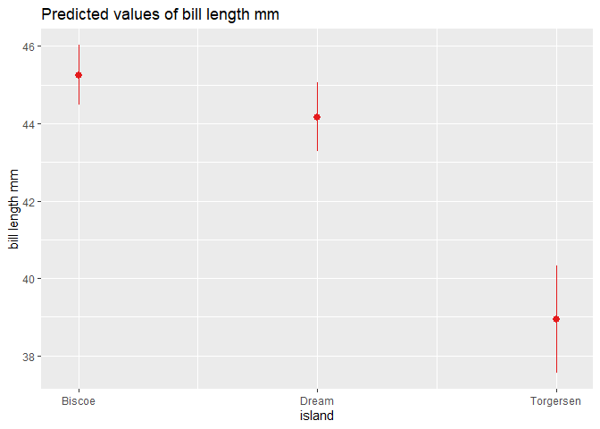

```r
eval(parse(text = 'reslist[[4]][[4]]'))
```

## 2.5 penguins.flipper_length_mm.sex

```r
eval(parse(text = 'reslist[[5]][[1]]'))
```

```
##
## Call:
## lm(formula = myformula, data = data)
##
## Coefficients:
## (Intercept)      sexmale
##     197.364        7.142
```

```r
eval(parse(text = 'reslist[[5]][[2]]'))
```

|  | flipper length mm |  |  |
| --- | --- | --- | --- |
| Predictors | Estimates | CI | p |
| (Intercept) | 197.36 | 195.29 – 199.44 | **<0.001** |
| sex [male] | 7.14 | 4.22 – 10.07 | **<0.001** |
| Observations | 333 |  |  |
| R<sup>2</sup> / R<sup>2</sup> adjusted | 0.065 / 0.062 |  |  |

```r
eval(parse(text = 'reslist[[5]][[3]]'))
```

```
## # A tibble: 2 × 5
##   term        estimate std.error statistic    p.value
##   <chr>          <dbl>     <dbl>     <dbl>      <dbl>
## 1 (Intercept)   197.        1.06    187.   0
## 2 sexmale         7.14      1.49      4.80 0.00000239
```

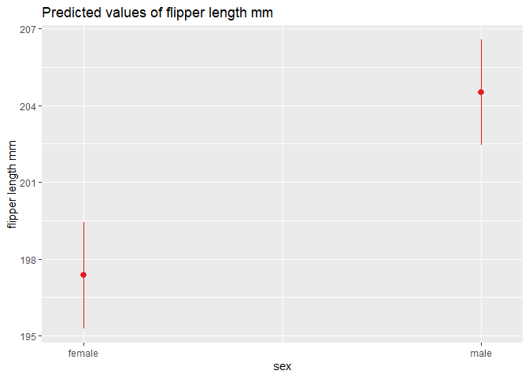

```r
eval(parse(text = 'reslist[[5]][[4]]'))
```

## 2.6 penguins.bill_length_mm.sex

```r
eval(parse(text = 'reslist[[6]][[1]]'))
```

```
##
## Call:
## lm(formula = myformula, data = data)
##
## Coefficients:
## (Intercept)      sexmale
##      42.097        3.758
```

```r
eval(parse(text = 'reslist[[6]][[2]]'))
```

|  | bill length mm |  |  |
| --- | --- | --- | --- |
| Predictors | Estimates | CI | p |
| (Intercept) | 42.10 | 41.31 – 42.88 | **<0.001** |
| sex [male] | 3.76 | 2.65 – 4.87 | **<0.001** |
| Observations | 333 |  |  |
| R<sup>2</sup> / R<sup>2</sup> adjusted | 0.118 / 0.116 |  |  |

```r
eval(parse(text = 'reslist[[6]][[3]]'))
```

```
## # A tibble: 2 × 5
##   term        estimate std.error statistic   p.value
##   <chr>          <dbl>     <dbl>     <dbl>     <dbl>
## 1 (Intercept)    42.1      0.400    105.   2.18e-256
## 2 sexmale         3.76     0.564      6.67 1.09e- 10
```

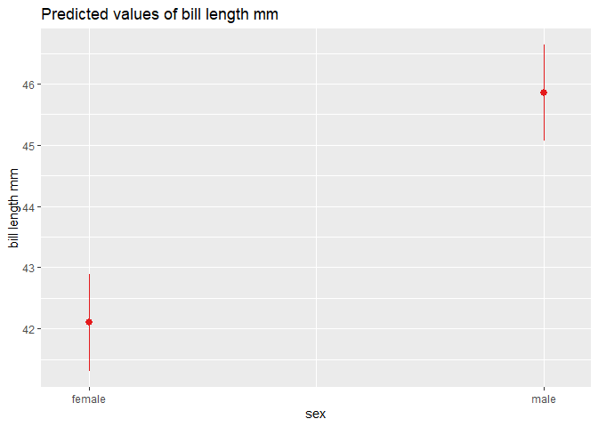

```r
eval(parse(text = 'reslist[[6]][[4]]'))
```

# 3 Examples with built-in functions

The package includes built-in functions in order to perform bivariate analyses with weighted data.

If the dependent variable is numeric, results will show:

- grouped descriptive statistics
- grouped boxplots

Results are organized into tabsets, like in the following example:

## 3.1 Bivariates by sex

```r
myres <- fabrica_chunks(
  vd = c("bill_length_mm", "bill_depth_mm", "flipper_length_mm"),
  vi = c("sex"),
  d = "penguins",
  w = "pes")
```

`myres` generates a vector character containing the code that will be later evaluated with `knit_child`

### 3.1.1 bill_length_mm x sex

```r
eval(parse(text = (reslist_mytab[[1]][[1]])))
```

```
## # A tibble: 3 × 9
##   sex        n     N mitjana mediana desv_tip margin lower upper
##   <fct>  <int> <dbl>   <dbl>   <dbl>    <dbl>  <dbl> <dbl> <dbl>
## 1 female   165   165    42.1    42.8     4.90  0.754  41.3  42.9
## 2 male     168   168    45.9    46.8     5.37  0.817  45.0  46.7
## 3 <NA>      11    11    41.3    42       4.63  3.07   38.2  44.4
```

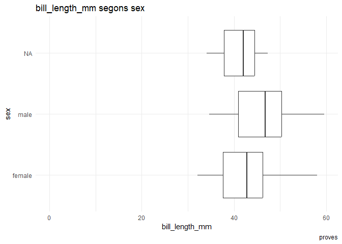

```r
eval(parse(text = (reslist_mytab[[1]][[2]])))
```

### 3.1.2 bill_depth_mm x sex

```r
eval(parse(text = (reslist_mytab[[2]][[1]])))
```

```
## # A tibble: 3 × 9
##   sex        n     N mitjana mediana desv_tip margin lower upper
##   <fct>  <int> <dbl>   <dbl>   <dbl>    <dbl>  <dbl> <dbl> <dbl>
## 1 female   165   165    16.4    17       1.80  0.276  16.1  16.7
## 2 male     168   168    17.9    18.4     1.86  0.284  17.6  18.2
## 3 <NA>      11    11    16.6    17.1     2.24  1.48   15.2  18.1
```

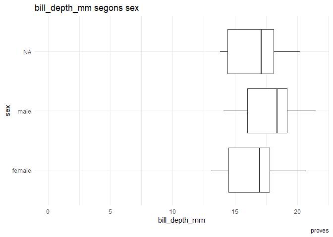

```r
eval(parse(text = (reslist_mytab[[2]][[2]])))
```

### 3.1.3 flipper_length_mm x sex

```r
eval(parse(text = (reslist_mytab[[3]][[1]])))
```

```
## # A tibble: 3 × 9
##   sex        n     N mitjana mediana desv_tip margin lower upper
##   <fct>  <int> <dbl>   <dbl>   <dbl>    <dbl>  <dbl> <dbl> <dbl>
## 1 female   165   165    197.    193      12.5   1.92  195.  199.
## 2 male     168   168    205.    200.     14.5   2.22  202.  207.
## 3 <NA>      11    11    199     193      16.5  10.9   188.  210.
```

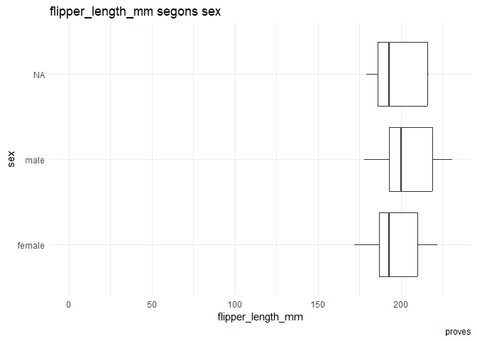

```r
eval(parse(text = (reslist_mytab[[3]][[2]])))
```

## 3.2 Bivariates by island

```r
myres <- fabrica_chunks(
  vd = c("sex", "species"),
  vi = c("island"),
  d = "penguins",
  w = "pes")
```

### 3.2.1 sex x island

```r
eval(parse(text = (reslist_mytab[[1]][[1]])))
```

```
## # A tibble: 6 × 7
##   VI        VD         N     n    TT    PP  ASres
##   <chr>     <chr>  <dbl> <int> <dbl> <dbl>  <dbl>
## 1 Biscoe    female    80    80   163  49.1 -0.167
## 2 Biscoe    male      83    83   163  50.9  0.167
## 3 Dream     female    61    61   123  49.6  0.012
## 4 Dream     male      62    62   123  50.4 -0.013
## 5 Torgersen female    24    24    47  51.1  0.225
## 6 Torgersen male      23    23    47  48.9 -0.224
```

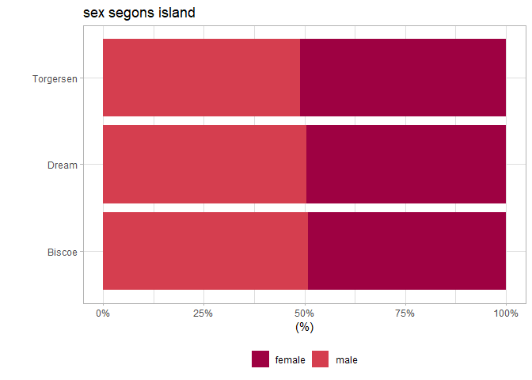

```r
eval(parse(text = (reslist_mytab[[1]][[2]])))
```

### 3.2.2 species x island

```r
eval(parse(text = (reslist_mytab[[2]][[1]])))
```

```
## # A tibble: 5 × 7
##   VI        VD            N     n    TT    PP  ASres
##   <chr>     <chr>     <dbl> <int> <dbl> <dbl>  <dbl>
## 1 Biscoe    Adelie       44    44   168  26.2 -6.57
## 2 Biscoe    Gentoo      124   124   168  73.8 14.3
## 3 Dream     Adelie       56    56   124  45.2  0.273
## 4 Dream     Chinstrap    68    68   124  54.8 12.3
## 5 Torgersen Adelie       52    52    52 100    8.80
```

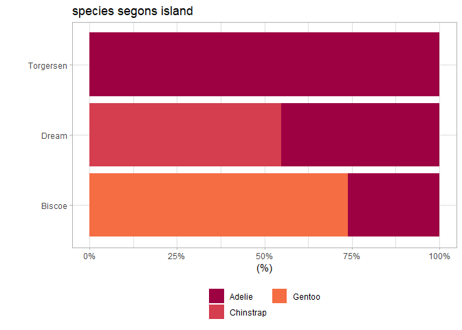

```r
eval(parse(text = (reslist_mytab[[2]][[2]])))
```